# take-home exam

## Problem 7

Fit a decision tree to the training data in order to separate the two classes. Prune the tree using cross validation and make sure that there are no redundant splits (splits that lead to leaves with the same classification). Then estimate the classification error rate for the pruned tree from the test data.

```r
set.seed(100)
tree.oj <- tree(cover~., data=covtype.train)
cv.oj <- cv.tree(tree.oj, FUN=prune.misclass)
```

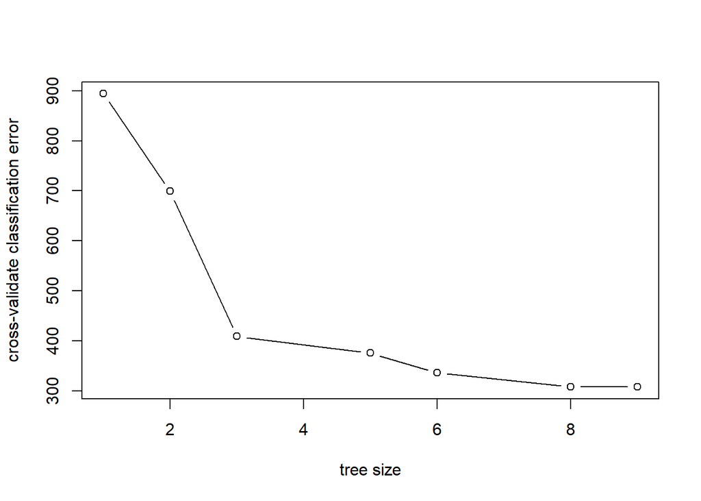

```r
plot(x=cv.oj$size, y=cv.oj$dev, type='b', xlab='tree size', ylab='cross-validate classification error')
```

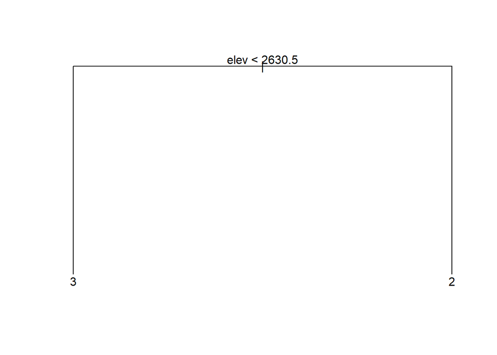

```r
prune.oj <- prune.misclass(tree.oj, best=2)
plot(prune.oj)
text(prune.oj, pretty=0)
```

```r
# Measures evaluated on test data
pred <- predict(prune.oj, newdata=covtype.test, type='class')
con <- table(predict=pred, actual=covtype.test$cover)
specificity <- con[1]/(con[1] + con[3])
sensitivity <- con[4]/(con[4] + con[2])
cat('specificity:', specificity)
```

```
## specificity: 0.9836224
```

```r
cat('\nsensitivity:', sensitivity)
```

```
##
## sensitivity: 0.6008255
```

```r
error_rate <- (con[3]+con[2])/sum(con)
cat('\nerror rate:', error_rate)
```

```
##
## error rate: 0.0813
```

## Problem 8

Fit a random forest model to the training data in order to separate the classes. Identify the ten most important variables and fit another random forest model, using only these variables. Use the test data to decide which model has better performance.

THe model with the 10 most important variables had lower test error rate and higher sensitivity.

```r
rf.covtype <- randomForest(cover~., mtry=4, data=covtype.train)
```

```r
imp_order <- order(-rf.covtype$importance)
names <- rownames(rf.covtype$importance)[imp_order][1:10]
names
```

```
##  [1] "elev"        "wild4"       "soil4"       "soil2"       "h_dist_fire"
##  [6] "h_dist_road" "soil10"      "wild1"       "slope"       "wild3"
```

```r
rf.covtype.imp <- randomForest(cover~elev+wild4+soil4+soil2+h_dist_fire+h_dist_road+soil10+wild1+slope+wild3, mtry=4, data=covtype.train)
```

```r
# Measures evaluated on test data
pred <- predict(rf.covtype, newdata=covtype.test, type='class')
con <- table(predict=pred, actual=covtype.test$cover)
specificity <- con[1]/(con[1] + con[3])
sensitivity <- con[4]/(con[4] + con[2])
cat('first model specificity:', specificity)
```

```
## first model specificity: 0.9853157
```

```r
cat('\nfirst model sensitivity:', sensitivity)
```

```
##
## first model sensitivity: 0.8936356
```

```r
error_rate <- (con[3]+con[2])/sum(con)
cat('\nfirst model error rate:', error_rate)
```

```
##
## first model error rate: 0.0252
```

```r
# Measures evaluated on test data
pred <- predict(rf.covtype.imp, newdata=covtype.test, type='class')
con <- table(predict=pred, actual=covtype.test$cover)
specificity <- con[1]/(con[1] + con[3])
sensitivity <- con[4]/(con[4] + con[2])
cat('second model specificity:', specificity)
```

```
## second model specificity: 0.9845257
```

```r
cat('\nsecond model sensitivity:', sensitivity)
```

```
##
## second model sensitivity: 0.9399261
```

```r
error_rate <- (con[3]+con[2])/sum(con)
cat('\nsecond model error rate:', error_rate)
```

```
##
## second model error rate: 0.0203
```

# Part 3: MNIST Digit Data

Problems 9 and 10 use the MNIST image classification data, available as mnist_all.RData in Canvas. We use only the test data (10000 images).

## Problem 9

### (a)

Select a random subset of 1000 digits. Use hierarchical clustering with complete linkage on these images and visualize the dendrogram.

```r
set.seed(100)
idx <- sample(10000, 1000)
sample_x <- test$x[idx,]
sample_y <- test$y[idx]
```

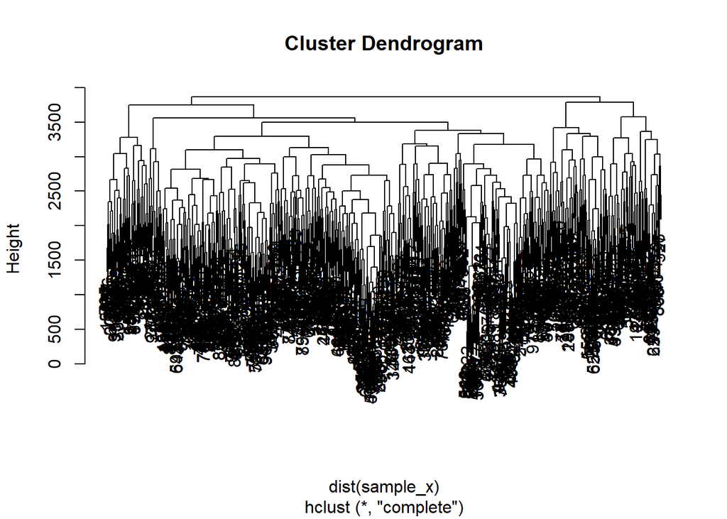

```r
hc <- hclust(dist(sample_x), method='complete')
plot(hc)
```

### (b)

Does the dendrogram provide compelling evidence about the correct number of clusters? Explain your answer.

No. Because the dendrogram can be cut at any spot along the height to give different number of clusters.

### (c)

Cut the dendrogram to generate a set of clusters that appears to be reasonable. There should be between 5 and 15 clusters. Then find a way to create a visual representation of each cluster. Explain and describe your approach.

The p predictors are projected into 2 discriminant components, which is then plotted below. This is used to visualize the 10 clusters in a 2-dimensional graph.

```r
library(cluster)
library(fpc)
```

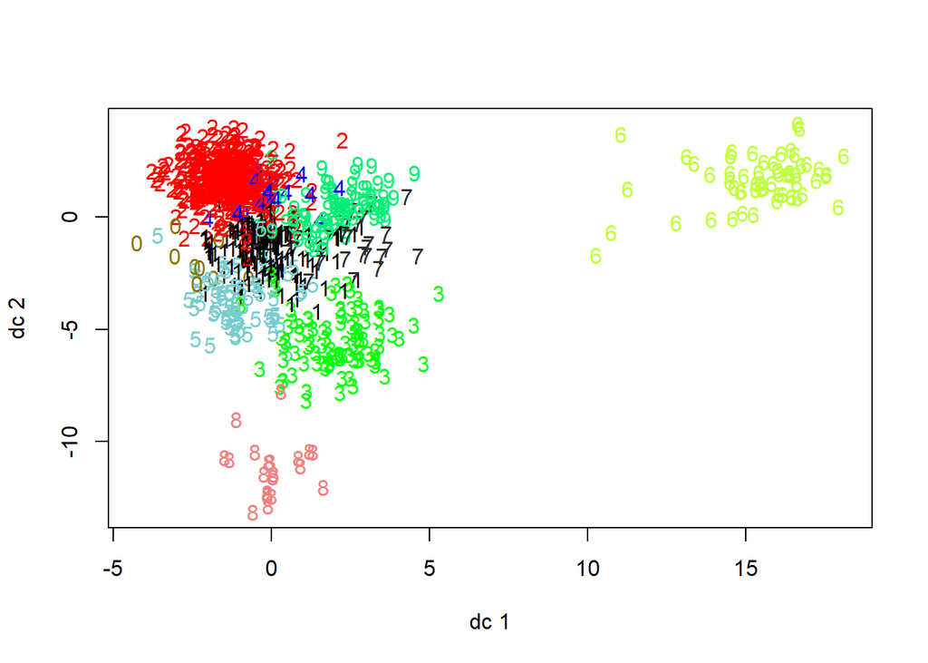

```r
hc.cut <- cutree(hc, k=10)
plotcluster(sample_x, hc.cut)
```

## Problem 10

Use Principal Component Analysis on the MNIST images.

### (a)

Make a plot of the proportion of variance explained vs number of principal compnents. Which fraction of the variance is explained by the first two principal components? Which fraction is explained by the first 10 principal components?

Juding by the plots, it looks like the first 2 principal components exlain about 12% of the total variance. The first 10 principal components explain about 30% of the total variance.

```r
test.x <- test$x
vars <- apply(test.x, MARGIN=2, var)
var.0 <- vars != 0
test.x <- test.x[,var.0]
```

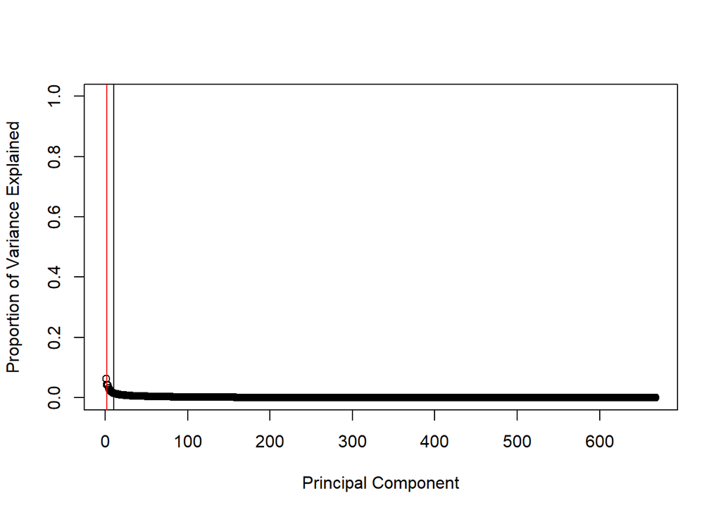

```r
pr.mnist <- prcomp(test.x, scale=T)
pr.var <- pr.mnist$sdev^2
pve <- pr.var/sum(pr.var)
plot(pve, xlab='Principal Component', ylab='Proportion of Variance Explained', ylim=c(0,1),
     type='b')
abline(v=2, col='red')
abline(v=10)
```

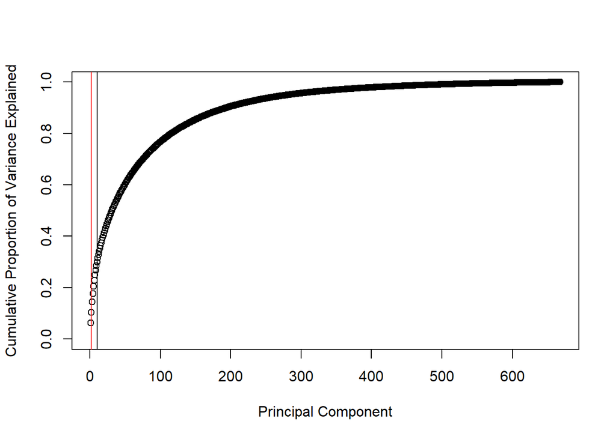

```r
plot(cumsum(pve), xlab='Principal Component', ylab='Cumulative Proportion of Variance Explained', ylim=c(0,1),
     type='b')
abline(v=2, col='red')
abline(v=10)
```

### (b)

Plot the scores of the first 2 principal components of all digits against each other, color coded by the digit that is represented. Comment on the plot. Does it appear that digits may be separated by these scores?

The figure shows that a lot of digits are overlapping, so it would be difficult to separate all digits using these scores.

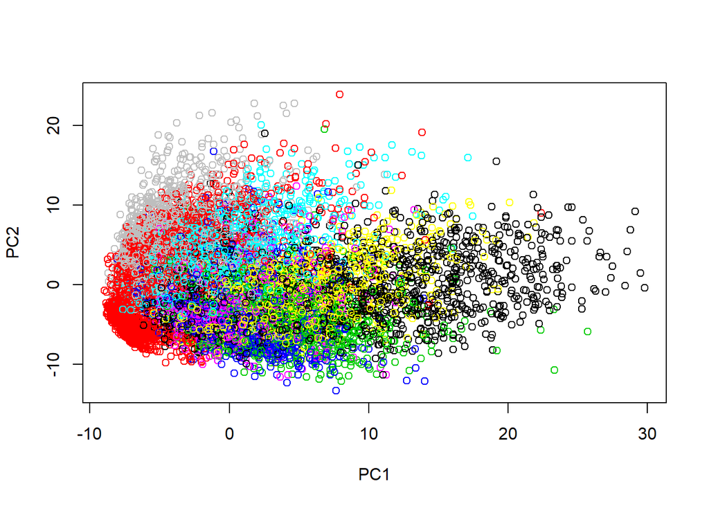

```r
scores <- data.frame(test$y, pr.mnist$x[,1:2])
plot(x=scores$PC1, y=scores$PC2, col=factor(scores$test.y), xlab='PC1', ylab='PC2')
```

### (c)

Find three digits which are reasonably well separated by the plot that you made in part (b). Illustrate this with a color coded plot like the one in (b) for just these 3 digits. Don’t expect perfect separation.

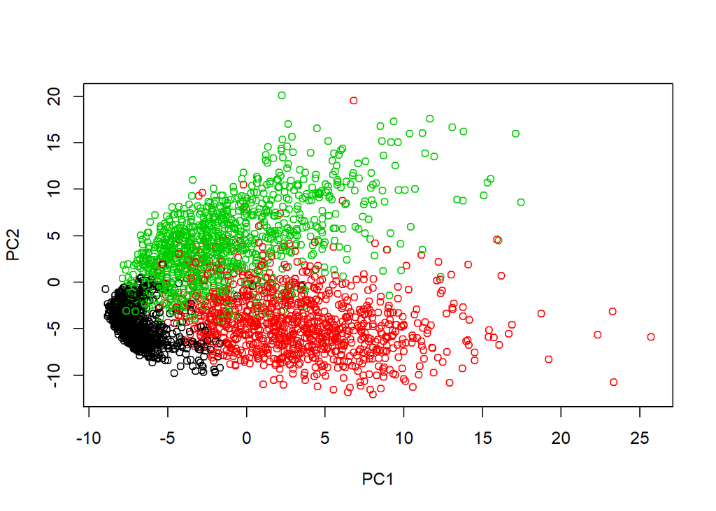

```r
temp <- scores[scores$test.y %in% c(1,2,4),]
plot(x=temp$PC1, y=temp$PC2, col=factor(temp$test.y), xlab='PC1', ylab='PC2')
```

### (d)

Find three other digits which are not well separated by the plot that you made in part (b). Illustrate this with another color coded plot like the one in (b) for just these three digits.

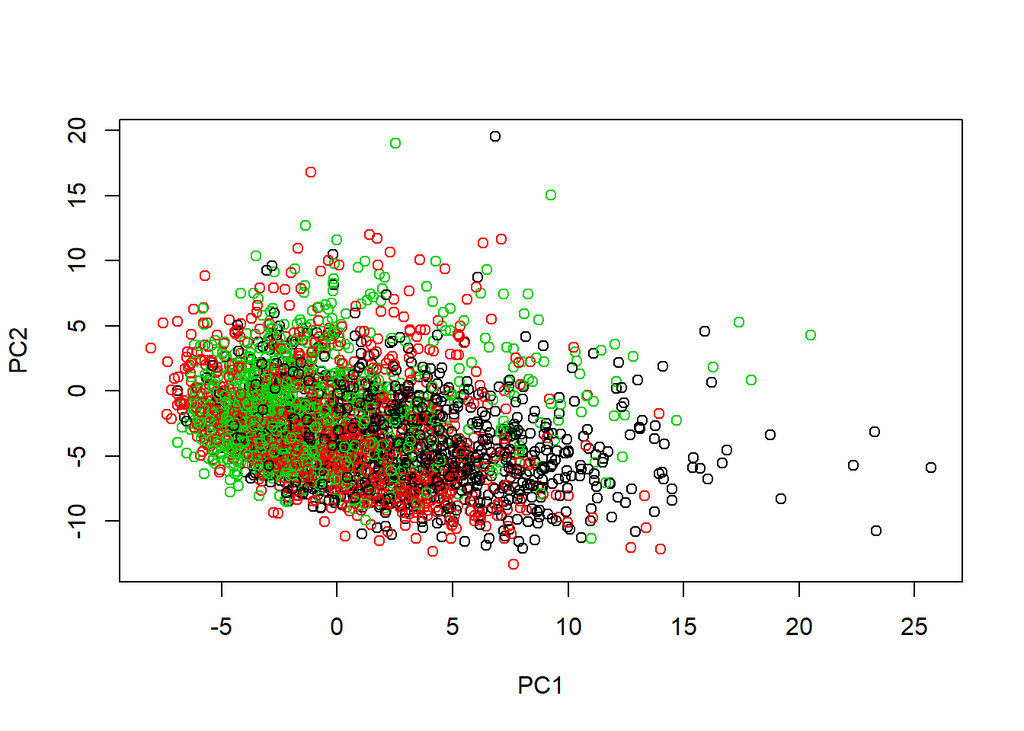

```r
temp <- scores[scores$test.y %in% c(3,2,8),]
plot(x=temp$PC1, y=temp$PC2, col=factor(temp$test.y), xlab='PC1', ylab='PC2')
```